# ECOM90024 - Assignment 3 - Question 3

## f) Using conditional varince forecasts from your ARCH/GARCH model, compute and plot h-step ahead point and 95% interval forecasts for the daily returns for h = 1, 2, …, 10.

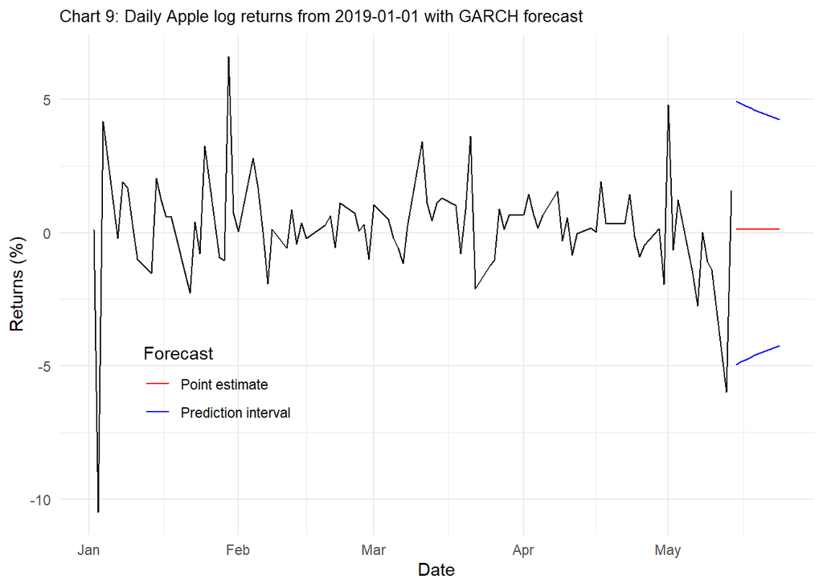

```r
################################# CREATING FINAL MODEL #########################

final_model <- ugarchspec(

  variance.model = list(model ="sGARCH", garchOrder = c(1,1)),

  mean.model = list(armaOrder = c(0,0), include.mean = TRUE),

  distribution.model = "norm"

)

############################# FORECASTING VALUES ###############################


data_fc <- data_fc %>%
  select(date)

final_model_forecast_fit <- ugarchfit(spec = final_model, data = data$returns)

final_model_forecast <- ugarchforecast(final_model_forecast_fit, n.ahead = 10)



############################## EXTRACTING MODEL OUTPUTS ########################


cond_mean_forecast <- data.frame(final_model_forecast@forecast$seriesFor) %>%  clean_names() %>%
  select(cond_mean = x1972_10_03)

cond_var_forecast <- data.frame(final_model_forecast@forecast$sigmaFor) %>%
  clean_names() %>%
  select(cond_var = x1972_10_03) %>%
    mutate(upper_interval = cond_var * 1.96) %>%
  mutate(lower_interval = cond_var * -1.96) %>%
  select(upper_interval, lower_interval)


garch_forecast <- cond_mean_forecast %>%
  cbind(cond_var_forecast)


######################### COMBINING INTO FORECAST FOR PLOT #####################

data_fc <- data_fc %>%
  cbind(garch_forecast)


data_final_garch <- data %>%
  full_join(data_fc, by = "date") %>%
  filter(date >= "2019-01-01")


################################## CHARTING ####################################

garch_fc <- ggplot(data_final_garch, aes(x = date)) +
  geom_line(aes(y = returns)) +
  geom_line(aes(y = cond_mean, colour = "Point estimate")) +
  geom_line(aes(y = upper_interval, colour = "Prediction interval")) +
  geom_line(aes(y = lower_interval, colour = "Prediction interval")) +


    scale_colour_manual(name = "Forecast", values = c("Point estimate" = "red", "Prediction interval" = "blue")) +

    ggtitle("Chart 9: Daily Apple log returns from 2019-01-01 with GARCH forecast")+
  ylab("Returns (%)") +
  xlab("Date") +
      theme(plot.title = element_text(size = 10),
        plot.caption = element_text(hjust = 0),
        legend.position = c(0.1, 0.4),
        legend.justification = c(0, 1))

garch_fc
```

## g) Compare the forecast intervals from part (c) with those from part (f). Do you observe any difference?

- Chart 2 and Chart 9 have been replicated below for ease of refernce.
  - The key difference between the forecast intervals between them is that in the GARCH model forecast, the intervals are sloping downwards whereas they are constant for the mean equation forecast.
  - The reason mean equation forecast has constant variance is because that is a requirement for effecively modelling using an ARIMA model: variance must be constant. Therefore, by definition, these models are unable to show any time variance.
  - In comparison, the reason the variance is not constant is because the objective of GARCH models is to model conditional (i.e. time varying) variance. Specifically, it slopes downwards due to the nature of how volatility is modelled. That is, GARCH models incorporate mean reversion of volatility, which means that while volatility can spike in the short term due ot shocks, it is always expected to revert to a long-run average over time. Furthermore, given our time series is stationary, therefore this conditional variance will always revert back to its unconditional variance following the unwinding of shocks.

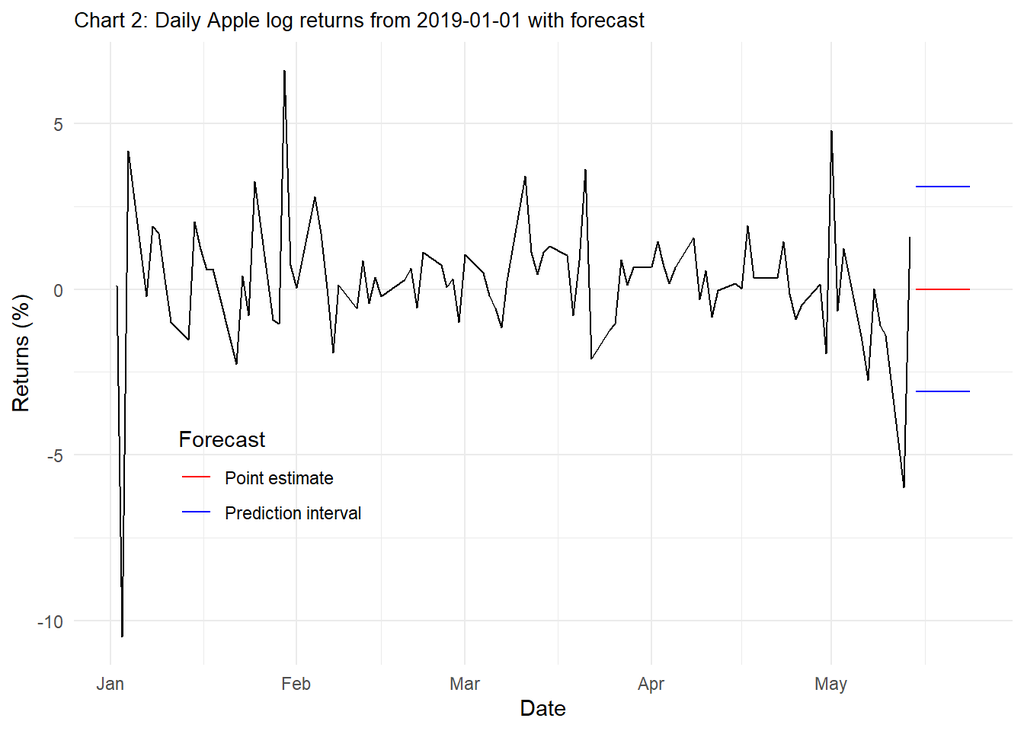

```r
mean_eqn_fc
```

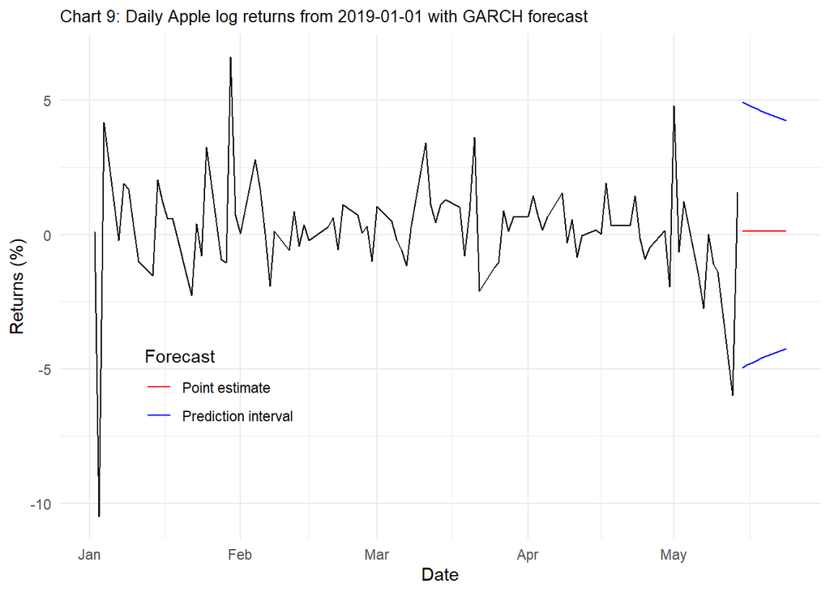

```r
garch_fc
```